# ATAC-seq exploration

Kaisu Hiltunen

2023/05/3

```r
suppressPackageStartupMessages({
  library(GenomicRanges) #for cleanung the motif list
  library(Rsamtools)
  library(epiwraps)
  library(motifmatchr)
  library(MotifDb)
  library(universalmotif)
  library(sechm)
  library(BiocParallel)
  library(ggplot2)
  library(chromVAR) # for motif accessibility estimation
  library(SummarizedExperiment) # data structure
  library(limma) # for statistical analysis
  library(AnnotationHub)
})
```

```
## See system.file("LICENSE", package="MotifDb") for use restrictions.
```

```r
# to control multithreading, unix users can use:
# register(MulticoreParam(4))
# for windows users, rather one of the following:
register(SerialParam())
# register(SnowParam(2))
```

## Download the data

```r
options(timeout=6000)
download.file("https://ethz-ins.org/content/mouse_mm38_hippocampus.peakCounts.SE.rds", "hippocampus_peakCounts.SE.rds", mode="wb")
```

```r
se <- readRDS("hippocampus_peakCounts.SE.rds")
```

## Get the database of motifs

```r
#concentrate on one source and specify species
#although species is semi trivial
motifs <- MotifDb::query(MotifDb, c("HOCOMOCOv11-core", "Hsapiens"))
```

```r
#get a set of motifs in this specific format and rename the motifs with genesymbol
motifs <- do.call(TFBSTools::PWMatrixList, setNames(
           universalmotif::convert_motifs(motifs, class="TFBSTools-PWMatrix"),
           mcols(motifs)$geneSymbol))
```

```r
# preparing the genome sequence file
#mouse ensembl GRCm38 genome

options(timeout=6000)
ah<-AnnotationHub()
```

```
## snapshotDate(): 2022-10-31
```

```r
#q<-AnnotationHub::query(ah, c("mus","ensembl","GRCm38"))


genome<-ah[["AH68356"]]
```

```
## loading from cache
```

```
## require("rtracklayer")
```

```r
genome_seq<-rtracklayer::import(genome)
```

# How to estimate the accessibility

1. get the fragment counts for each peak in each sample -> add GC bias
2. get the occurence of each motif in each peak
3. use 1 and 2 to obtain aggregated motif score per sample

```r
colData(se)
```

```
## DataFrame with 12 rows and 1 column
##                                   depth
##                               <numeric>
## Control_female_GSM6041841.bam  73170149
## Control_female_GSM6041842.bam  93995034
## Control_female_GSM6041843.bam  40167775
## Control_male_GSM6041844.bam    70491005
## Control_male_GSM6041845.bam    84985977
## ...                                 ...
## FSS_female_GSM6041854.bam      73674456
## FSS_female_GSM6041855.bam      49285912
## FSS_male_GSM6041856.bam        82385764
## FSS_male_GSM6041857.bam        68623011
## FSS_male_GSM6041858.bam        81801232
```

```r
#extract the annotation of rows
names<-se@colData@rownames

#save conditions in vector
conditions<-lapply(strsplit(names[],split="_"), function(l) l[[1]])

#create column for condition data
colData(se)$conditions<-conditions

#same for sex
sex<-lapply(strsplit(names[],split="_"), function(l) l[[2]])
colData(se)$sex<-sex
```

```r
#add gc bias to the object
se<- chromVAR::addGCBias(se, genome=genome_seq)
#we see that we added the bias column
rowRanges(se)
```

```
## GRanges object with 20660 ranges and 1 metadata column:
##           seqnames            ranges strand |      bias
##              <Rle>         <IRanges>  <Rle> | <numeric>
##       [1]        1   3012609-3012858      * |     0.348
##       [2]        1   3094941-3095190      * |     0.424
##       [3]        1   3113634-3113883      * |     0.448
##       [4]        1   3119522-3119771      * |     0.448
##       [5]        1   3119880-3120129      * |     0.432
##       ...      ...               ...    ... .       ...
##   [20656]        Y 90744317-90744566      * |     0.636
##   [20657]        Y 90744689-90744938      * |     0.544
##   [20658]        Y 90761326-90761575      * |     0.640
##   [20659]        Y 90804984-90805233      * |     0.472
##   [20660]        Y 90808700-90808949      * |     0.416
##   -------
##   seqinfo: 30 sequences from an unspecified genome; no seqlengths
```

```r
#try to find which peaks contain which motifs
#we dont use "out=positions"
moi <- motifmatchr::matchMotifs(motifs, subject=se, genome=genome_seq)
```

# 3

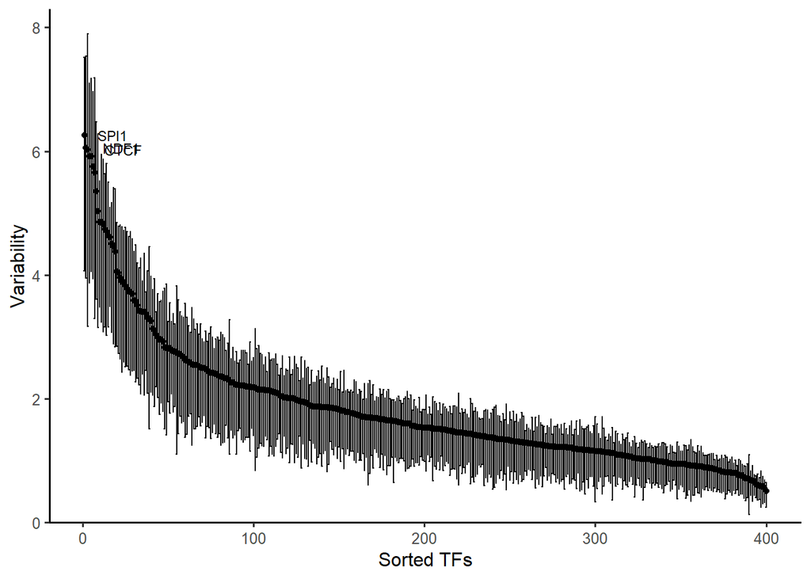

```r
dev <- chromVAR::computeDeviations(se, annotations = moi, background_peaks=getBackgroundPeaks(se,niterations=1000))


variability <- chromVAR::computeVariability(dev)
chromVAR::plotVariability(variability)
```

```r
assays(dev)$norm <- scale(assays(dev)$z)
dev
```

```
## class: chromVARDeviations
## dim: 400 12
## metadata(0):
## assays(3): deviations z norm
## rownames(400): AHR AIRE ... ZNF8 ZSC22
## rowData names(3): name fractionMatches fractionBackgroundOverlap
## colnames(12): Control_female_GSM6041841.bam
##   Control_female_GSM6041842.bam ... FSS_male_GSM6041857.bam
##   FSS_male_GSM6041858.bam
## colData names(3): depth conditions sex
```

# Differential analysis

With limma For each run t-test to find out if this motif is differentially expressed

```r
#apply the factor function to turn the list of conditions to integer presentation
dev$conditions <- factor(unlist(dev$conditions))

#reorder the levels of the factor variable dev$conditions such that "Control" becomes the reference level.
dev$conditions <- relevel(dev$conditions, "Control")

#We create a model matrix mm1 for the variable conditions using the function model.matrix().
#The formula ~conditions specifies that the variable conditions is the predictor or independent variable in the linear model.
mm1 <- model.matrix(~conditions, colData(dev))

#same for the sex
dev$sex <- factor(unlist(dev$sex))
dev$sex <- relevel(dev$sex, "female")
mm2<- model.matrix(~sex, colData(dev))
```

## Comparing stressed and control animals

The stressed animals are denoted ‘FSS’ – forced swim stress.

```r
fit <- eBayes(lmFit(assays(dev)$norm, mm1))
res_condition <-topTable(fit, coef = "conditionsFSS", number=Inf)
head(res_condition)
```

```
##            logFC     AveExpr         t      P.Value  adj.P.Val         B
## GCR    4.3884998  0.20688218  5.530886 7.036374e-05 0.01920219  1.878984
## PRGR   3.5585299  0.25279786  5.359453 9.601095e-05 0.01920219  1.597004
## MEF2C -1.1578514 -0.12669967 -2.463063 2.714013e-02 0.99874186 -3.582593
## MEF2A -0.9318621 -0.05151990 -2.159301 4.840840e-02 0.99874186 -4.094588
## CDX1   0.8465219  0.03043444  2.158437 4.848679e-02 0.99874186 -4.096002
## MEF2D -1.1485723 -0.06414279 -2.158048 4.852211e-02 0.99874186 -4.096639
```

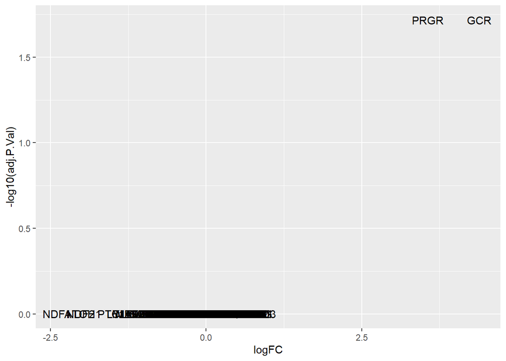

```r
res_condition$TF<-row.names(res_condition)
ggplot(res_condition, aes(logFC, -log10(adj.P.Val), label=TF)) + geom_text()
```

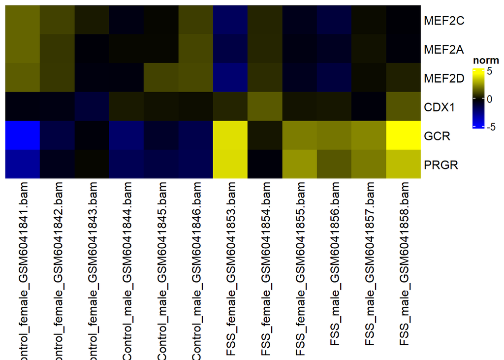

```r
sechm(dev, features=head(row.names(res_condition)),assayName="norm", show_colnames = TRUE)
```

## comparing females and males